# Surviving the Titanic!

Todd K Hartman

Last updated 2024-04-24

For today’s lab, we’re going to use a famous dataset and example, namely surviving the Titanic disaster. As you might have guessed, we’re going to model factors that might help us understand why some passengers survived while others did not. Many datasets about the sinking of the Titanic are available online, but we’re going to use the one from Kaggle, which is a popular data science website.

The Titanic data can be found here: (https://www.kaggle.com/c/titanic)[(https://www.kaggle.com/c/titanic)].

| Data | Dictionary |
| --- | --- |
| Variable | Definition |
| survival | Survival (0 = No, 1 = Yes) |
| pclass | Ticket class (1 = 1st, 2 = 2nd, 3 = 3rd) |
| sex | Sex |
| Age | Age in years |
| sibsp | Number of siblings / spouses aboard |
| parch | Number of parents / children aboard |
| ticket | Ticket number |
| fare | Passenger fare |
| cabin | Cabin number |
| embarked | Port (C = Cherbourg, Q = Queenstown, S = Southampton) |

Let’s begin by loading the necessary packages. We’re going to install and/or load packages using the ‘pacman’ package, which is a great tool for managing packages in R. If you don’t have ‘pacman’ installed, then you can do so by uncommenting and running the following code: `install.packages("pacman")`.

```r
## Install 'pacman' package if you don't already have it
# install.packages("pacman")

## Load necessary packages
## jtools: For creating a codebook
## knitr: For creating reproducible reports
## magrittr: For piping data; e.g., using the %<>% operator
## mice: For imputing missing values
## sjPlot: For creating summary tables
## tidyverse: For data manipulation
pacman::p_load(jtools, knitr, magrittr, mice, sjPlot, tidyverse)
```

In data science, data is often divided into two parts: training and testing datasets. The training dataset is used to build the model, while the testing dataset is used to evaluate the model’s performance. This helps us avoid overfitting the model to the training data.

Let’s use it to create a codebook for the ‘train’ dataset, which contains values for the `Survival` outcome:

```r
## Load the 'train' dataset
train <- read.csv("train.csv")

## Check the data using the 'glimpse()' function from the 'tidyverse' package
glimpse(train)
```

```
## Rows: 891
## Columns: 12
## $ PassengerId <int> 1, 2, 3, 4, 5, 6, 7, 8, 9, 10, 11, 12, 13, 14, 15, 16, 17,…
## $ Survived    <int> 0, 1, 1, 1, 0, 0, 0, 0, 1, 1, 1, 1, 0, 0, 0, 1, 0, 1, 0, 1…
## $ Pclass      <int> 3, 1, 3, 1, 3, 3, 1, 3, 3, 2, 3, 1, 3, 3, 3, 2, 3, 2, 3, 3…
## $ Name        <chr> "Braund, Mr. Owen Harris", "Cumings, Mrs. John Bradley (Fl…
## $ Sex         <chr> "male", "female", "female", "female", "male", "male", "mal…
## $ Age         <dbl> 22, 38, 26, 35, 35, NA, 54, 2, 27, 14, 4, 58, 20, 39, 14, …
## $ SibSp       <int> 1, 1, 0, 1, 0, 0, 0, 3, 0, 1, 1, 0, 0, 1, 0, 0, 4, 0, 1, 0…
## $ Parch       <int> 0, 0, 0, 0, 0, 0, 0, 1, 2, 0, 1, 0, 0, 5, 0, 0, 1, 0, 0, 0…
## $ Ticket      <chr> "A/5 21171", "PC 17599", "STON/O2. 3101282", "113803", "37…
## $ Fare        <dbl> 7.2500, 71.2833, 7.9250, 53.1000, 8.0500, 8.4583, 51.8625,…
## $ Cabin       <chr> "", "C85", "", "C123", "", "", "E46", "", "", "", "G6", "C…
## $ Embarked    <chr> "S", "C", "S", "S", "S", "Q", "S", "S", "S", "C", "S", "S"…
```

```r
## Create a codebook from the sjPlot package
## The 'view_df()' function creates an .html codebook for the dataset
## that appears in the Viewer pane in RStudio; if you click the
## 'show in new window button', the codebook will be opened
## in your default browser
view_df(train)
```

Data frame: train

[output not shown]

Our outcome of interest will be a binary variable indicating whether a person survived (`Survived = 1`) or perished (`Survived = 0`) in the sinking of the Titanic. Let’s check some summary statistics for the primary dependent variable.

```r
## Check the DV in the training dataset
train %>%                                            # Pass 'train' data to...
  reframe(                                           # Create new data frame
    `Survived Titanic` = c('No: 0', 'Yes: 1'),       # Create labels for 0 and 1
    Frequency = table(Survived),                     # Frequency table
    Percent = prop.table(table(Survived) )*100       # Proportions
  )
```

| Survived Titanic | Frequency | Percent |
| --- | --- | --- |
| No: 0 | 549 | 61.61616 |
| Yes: 1 | 342 | 38.38384 |

Now we should check to see if there are any missing variables in the outcomes or predictors that might cause problems with our analyses.

```r
## Are there any missing values among potential predictors?
train %>%      # Pass the 'train' data to...
  is.na() %>%  # Find any missing values
  colSums()    # Sum NAs by columns
```

```
## PassengerId    Survived      Pclass        Name         Sex         Age
##           0           0           0           0           0         177
##       SibSp       Parch      Ticket        Fare       Cabin    Embarked
##           0           0           0           0           0           0
```

Hmmm…there appears to be many missing values for age (nearly 20% of cases!), which we might expect to be related to survival rates. From survivor accounts, we know, for example, that women and children were given priority for lifeboats; hence, they should be more likely to survive this disaster. Without a predictor variable for age, we might be missing a potentially important explanatory variable for Titanic survival rates. Of course, we could opt to delete these missing values, but that would be a waste of potentially valuable information for our model (cases in our model will be removed via listwise deletion).

Instead, we can use the ‘mice’ package to impute missing values for age. This package uses a technique called predictive mean matching (PMM) to fill in missing values based on values of other variables in the dataset. For example, suppose that we wanted to impute missing values for someone’s vote choice in a previous election. We could use what we know about their age, gender, and education to fill in these missing values for their vote choice. In the case of the Titanic dataset, we have less information available, but we can still try to use available data about a passenger’s class, fare, etc. to fill in missing values for their age.

Before we do that, however, we should create other variables that might be useful for our model. For instance, we need to dummy code the `Sex` variable, which is currently measured as a nominal variable. We can do this by creating a new variable called `female` that is equal to 1 if the passenger was a woman and 0 otherwise. We can also generate dummy variables for the `Pclass` indicator, by creating two new variables called `first.class` and `second.class` that are equal to 1 if the passenger was in first or second class, respectively, and 0 otherwise.

We also might want to create a variable that indicates whether a passenger was traveling with family. We can do this by creating a new variable called ‘family’ that is equal to 1 if the passenger had any siblings or parents on board and 0 otherwise.

```r
## Create dummy variables for gender and class
train$female <- ifelse(train$Sex == 'female', 1, 0)
train$first.class <- ifelse(train$Pclass == 1, 1, 0)
train$second.class <- ifelse(train$Pclass == 2, 1, 0)

## Create 'family' variable to test whether having family on board
## impacted survival rates. Use the double pipe operator from 'magrittr'
## package, which passes data but also overwrites data with subsequent operations
train %<>%                                 # %<>% is the same as: train2 <- train2 %>%)
  mutate(                                         # Add variables to existing dataset
    family = ifelse(SibSp > 0 | Parch > 0, 1, 0)  # If passenger has any family on board
  )

table(train$family)
```

```
##
##   0   1
## 537 354
```

Let’s now impute age based on several other predictor variables.

```r
## We can use the 'mice' package to IMPUTE (i.e., fill in) missing values for age
## But let's not use all variables for this imputation process;
## Some variables are not helpful or analysable (e.g., PassengerId, ticket, etc.)

## Create a list of formulas for imputation needed for the 'mice' package
## Here we're specifying that age is a function of class, siblings, parents, and fare
form <- name.formulas(list(Age ~ female + first.class + second.class + family + Fare))

## Impute missing values for age using the 'mice' package
train.imputed <- train %>%
  select(Survived, Age, female, first.class, second.class, family, Fare) %>%
                      mice(              # Function
                      formulas = form,   # Variables to use for imputation
                      meth = 'pmm',      # Predictive mean matching
                      m = 10,            # Number of samples
                      maxit = 100,       # Maximum # of iterations
                      seed = 8675309     # For replication purposes
                      )
```

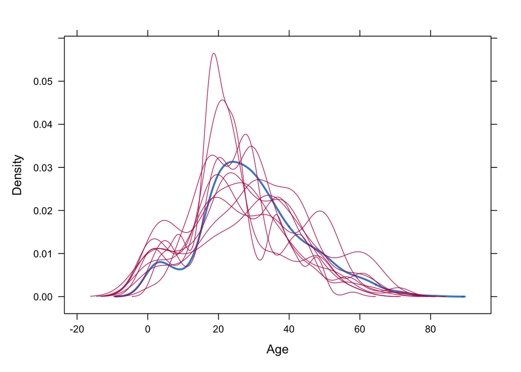

```r
train2 <- complete(train.imputed, 1)  # Add imputed values back to 'train' data

densityplot(train.imputed)  # Check the distribution of imputed ages from mice package
```

The density plot above shows the distribution of imputed ages from the ‘mice’ package. The imputed values are based on the values of other variables in the dataset. Ideally, the red and blue lines should overlap, indicating that the imputed values are similar to the observed values. The above figure shows that we’ve done an OK job of imputing missing values for age.

Now we’re ready to fit a logistic regression model to the Titanic data. We’re going to use the ‘glm()’ function from the ‘stats’ package to fit a logistic regression model to the data. The logistic regression model is a type of generalized linear model (GLM) that is used to model binary outcomes. In this case, we’re going to model the probability of survival as a function of several predictor variables.

```r
## Fit a Logistic Regression
log.fit <- glm(Survived ~ female + Age + first.class + second.class + family + Fare,
               family = "binomial",
               data = train2)
```

```r
summary(log.fit)  # Check the model results
```

```
##
## Call:
## glm(formula = Survived ~ female + Age + first.class + second.class +
##     family + Fare, family = "binomial", data = train2)
##
## Coefficients:
##                Estimate Std. Error z value Pr(>|z|)
## (Intercept)  -1.5143664  0.2287653  -6.620 3.60e-11 ***
## female        2.6124014  0.1946252  13.423  < 2e-16 ***
## Age          -0.0315729  0.0068896  -4.583 4.59e-06 ***
## first.class   2.4367925  0.2961212   8.229  < 2e-16 ***
## second.class  1.2765017  0.2281296   5.596 2.20e-08 ***
## family       -0.0680334  0.1930219  -0.352    0.724
## Fare          0.0006907  0.0021866   0.316    0.752
## ---
## Signif. codes:  0 '***' 0.001 '**' 0.01 '*' 0.05 '.' 0.1 ' ' 1
##
## (Dispersion parameter for binomial family taken to be 1)
##
##     Null deviance: 1186.66  on 890  degrees of freedom
## Residual deviance:  803.93  on 884  degrees of freedom
## AIC: 817.93
##
## Number of Fisher Scoring iterations: 5
```

```r
summ(log.fit, odds.ratio = TRUE)  # Obtain odds ratios for model coefficients
```

```
## MODEL INFO:
## Observations: 891
## Dependent Variable: Survived
## Type: Generalized linear model
##   Family: binomial
##   Link function: logit
##
## MODEL FIT:
## χ²(6) = 382.72, p = 0.00
## Pseudo-R² (Cragg-Uhler) = 0.47
## Pseudo-R² (McFadden) = 0.32
## AIC = 817.93, BIC = 851.48
##
## Standard errors: MLE
## -------------------------------------------------------------
##                      exp(Est.)   2.5%   97.5%   z val.      p
## ------------------ ----------- ------ ------- -------- ------
## (Intercept)               0.22   0.14    0.34    -6.62   0.00
## female                   13.63   9.31   19.96    13.42   0.00
## Age                       0.97   0.96    0.98    -4.58   0.00
## first.class              11.44   6.40   20.43     8.23   0.00
## second.class              3.58   2.29    5.60     5.60   0.00
## family                    0.93   0.64    1.36    -0.35   0.72
## Fare                      1.00   1.00    1.00     0.32   0.75
## -------------------------------------------------------------
```

Another way of interpretting the logistic regression coefficients is to calculate predicted probabilities of survival for different values of the predictor variables. We can do this by using the ‘predict()’ function from the ‘stats’ package. This function calculates the predicted probabilities of survival based on the logistic regression model we just fit. We can then use these predicted probabilities to calculate the average predicted probability of survival for different values of the predictor variables.

To create predicted probabilities we need to create a new data frame with the values we want the independent variables to take on to create our predictions.

```r
## Predicted probabilities of survival
## Make predictions from logistic regression model, check accuracy
train2$prob <- predict(log.fit,  # Predicted probabilities from model
                       newdata = train2,   # based on train2 dataset
                       type = "response")  # using responses

summary(train2$prob)  # Check predicted probabilities of survival range from 0 to 1
```

```
##    Min. 1st Qu.  Median    Mean 3rd Qu.    Max.
## 0.02093 0.10230 0.27816 0.38384 0.63341 0.97092
```

```r
## Now create a new data frame with the values we want the independent variables to take
## on to create our predictions; let's start with predicted probabilities for female
## passengers in first class who are traveling with family members
new.df <- with(train2,
  data.frame(female = c(0,1),        # Vary female dummy variable
             Age = mean(Age),        # Use mean age for predictions
             first.class = c(1,1),   # Set first class to 1
             second.class = c(0,0),  # Set second class to 0
             family = c(1,1),        # Set family to 1
             Fare = mean(Fare) )     # Use mean fare for predictions (might be wrong b/c first class chosen)
  )

## View data frame
new.df
```

| female | Age | first.class | second.class | family | Fare |
| --- | --- | --- | --- | --- | --- |
| 0 | 28.59929 | 1 | 0 | 1 | 32.20421 |
| 1 | 28.59929 | 1 | 0 | 1 | 32.20421 |

```r
## Calculate predicted probabilities of survival based on new data frame
new.df$prob <- predict(log.fit, newdata = new.df, type = "response")

## View predicted probabilities (i.e., predicted survival by )
new.df
```

| female | Age | first.class | second.class | family | Fare | prob |
| --- | --- | --- | --- | --- | --- | --- |
| 0 | 28.59929 | 1 | 0 | 1 | 32.20421 | 0.4934181 |
| 1 | 28.59929 | 1 | 0 | 1 | 32.20421 | 0.9299598 |

In the above example, the predicted probability of survival is above .90 for women in first class who are traveling with family members (and who paid an average fare). This is a very high probability of survival, which is consistent with survivor accounts of the Titanic disaster. For men, this probability of survival drops below .5 (a 50-50 chance of survival!). What other predicted probabilities can you calculate?